# Risk Factor Analysis

## Outcome Variable

**Outcome Variable:** y_rate_len

## Predictor Variables

**Intervention Variable:** predfeed36

**Adjustment Set:**

unadjusted

## Stratifying Variables

The analysis was stratified on these variable(s):

- agecat
- studyid
- country

## Data Summary

| agecat | studyid | country | predfeed36 | n_cell | n |
| --- | --- | --- | --- | --- | --- |
| 0-3 months | EE | PAKISTAN | 1 | 2 | 6 |
| 0-3 months | EE | PAKISTAN | 0 | 4 | 6 |
| 0-3 months | GMS-Nepal | NEPAL | 1 | 372 | 465 |
| 0-3 months | GMS-Nepal | NEPAL | 0 | 93 | 465 |
| 0-3 months | MAL-ED | BANGLADESH | 1 | 81 | 242 |
| 0-3 months | MAL-ED | BANGLADESH | 0 | 161 | 242 |
| 0-3 months | MAL-ED | BRAZIL | 1 | 19 | 167 |
| 0-3 months | MAL-ED | BRAZIL | 0 | 148 | 167 |
| 0-3 months | MAL-ED | INDIA | 1 | 11 | 181 |
| 0-3 months | MAL-ED | INDIA | 0 | 170 | 181 |
| 0-3 months | MAL-ED | NEPAL | 1 | 8 | 154 |
| 0-3 months | MAL-ED | NEPAL | 0 | 146 | 154 |
| 0-3 months | MAL-ED | PERU | 1 | 69 | 263 |
| 0-3 months | MAL-ED | PERU | 0 | 194 | 263 |
| 0-3 months | MAL-ED | SOUTH AFRICA | 1 | 1 | 209 |
| 0-3 months | MAL-ED | SOUTH AFRICA | 0 | 208 | 209 |
| 0-3 months | MAL-ED | TANZANIA, UNITED REPUBLIC OF | 1 | 3 | 223 |
| 0-3 months | MAL-ED | TANZANIA, UNITED REPUBLIC OF | 0 | 220 | 223 |
| 3-6 months | EE | PAKISTAN | 1 | 3 | 7 |
| 3-6 months | EE | PAKISTAN | 0 | 4 | 7 |
| 3-6 months | GMS-Nepal | NEPAL | 1 | 366 | 460 |
| 3-6 months | GMS-Nepal | NEPAL | 0 | 94 | 460 |
| 3-6 months | MAL-ED | BANGLADESH | 1 | 77 | 230 |
| 3-6 months | MAL-ED | BANGLADESH | 0 | 153 | 230 |
| 3-6 months | MAL-ED | BRAZIL | 1 | 25 | 208 |
| 3-6 months | MAL-ED | BRAZIL | 0 | 183 | 208 |
| 3-6 months | MAL-ED | INDIA | 1 | 17 | 228 |
| 3-6 months | MAL-ED | INDIA | 0 | 211 | 228 |
| 3-6 months | MAL-ED | NEPAL | 1 | 8 | 232 |
| 3-6 months | MAL-ED | NEPAL | 0 | 224 | 232 |

[output cut: 134 more lines]

The following strata were considered:

- agecat: 0-3 months, studyid: EE, country: PAKISTAN
- agecat: 0-3 months, studyid: GMS-Nepal, country: NEPAL
- agecat: 0-3 months, studyid: MAL-ED, country: BANGLADESH
- agecat: 0-3 months, studyid: MAL-ED, country: BRAZIL
- agecat: 0-3 months, studyid: MAL-ED, country: INDIA
- agecat: 0-3 months, studyid: MAL-ED, country: NEPAL
- agecat: 0-3 months, studyid: MAL-ED, country: PERU
- agecat: 0-3 months, studyid: MAL-ED, country: SOUTH AFRICA
- agecat: 0-3 months, studyid: MAL-ED, country: TANZANIA, UNITED REPUBLIC OF
- agecat: 12-15 months, studyid: EE, country: PAKISTAN
- agecat: 12-15 months, studyid: GMS-Nepal, country: NEPAL
- agecat: 12-15 months, studyid: LCNI-5, country: MALAWI
- agecat: 12-15 months, studyid: MAL-ED, country: BANGLADESH
- agecat: 12-15 months, studyid: MAL-ED, country: BRAZIL
- agecat: 12-15 months, studyid: MAL-ED, country: INDIA
- agecat: 12-15 months, studyid: MAL-ED, country: NEPAL
- agecat: 12-15 months, studyid: MAL-ED, country: PERU
- agecat: 12-15 months, studyid: MAL-ED, country: SOUTH AFRICA
- agecat: 12-15 months, studyid: MAL-ED, country: TANZANIA, UNITED REPUBLIC OF
- agecat: 12-15 months, studyid: SAS-FoodSuppl, country: INDIA
- agecat: 15-18 months, studyid: EE, country: PAKISTAN
- agecat: 15-18 months, studyid: GMS-Nepal, country: NEPAL
- agecat: 15-18 months, studyid: LCNI-5, country: MALAWI
- agecat: 15-18 months, studyid: MAL-ED, country: BANGLADESH
- agecat: 15-18 months, studyid: MAL-ED, country: BRAZIL
- agecat: 15-18 months, studyid: MAL-ED, country: INDIA
- agecat: 15-18 months, studyid: MAL-ED, country: NEPAL
- agecat: 15-18 months, studyid: MAL-ED, country: PERU
- agecat: 15-18 months, studyid: MAL-ED, country: SOUTH AFRICA
- agecat: 15-18 months, studyid: MAL-ED, country: TANZANIA, UNITED REPUBLIC OF
- agecat: 15-18 months, studyid: SAS-FoodSuppl, country: INDIA
- agecat: 18-21 months, studyid: EE, country: PAKISTAN
- agecat: 18-21 months, studyid: GMS-Nepal, country: NEPAL
- agecat: 18-21 months, studyid: LCNI-5, country: MALAWI
- agecat: 18-21 months, studyid: MAL-ED, country: BANGLADESH
- agecat: 18-21 months, studyid: MAL-ED, country: BRAZIL
- agecat: 18-21 months, studyid: MAL-ED, country: INDIA
- agecat: 18-21 months, studyid: MAL-ED, country: NEPAL
- agecat: 18-21 months, studyid: MAL-ED, country: PERU
- agecat: 18-21 months, studyid: MAL-ED, country: SOUTH AFRICA
- agecat: 18-21 months, studyid: MAL-ED, country: TANZANIA, UNITED REPUBLIC OF
- agecat: 21-24 months, studyid: EE, country: PAKISTAN
- agecat: 21-24 months, studyid: GMS-Nepal, country: NEPAL
- agecat: 21-24 months, studyid: LCNI-5, country: MALAWI
- agecat: 21-24 months, studyid: MAL-ED, country: BANGLADESH
- agecat: 21-24 months, studyid: MAL-ED, country: BRAZIL
- agecat: 21-24 months, studyid: MAL-ED, country: INDIA
- agecat: 21-24 months, studyid: MAL-ED, country: NEPAL
- agecat: 21-24 months, studyid: MAL-ED, country: PERU
- agecat: 21-24 months, studyid: MAL-ED, country: SOUTH AFRICA
- agecat: 21-24 months, studyid: MAL-ED, country: TANZANIA, UNITED REPUBLIC OF
- agecat: 3-6 months, studyid: EE, country: PAKISTAN
- agecat: 3-6 months, studyid: GMS-Nepal, country: NEPAL
- agecat: 3-6 months, studyid: MAL-ED, country: BANGLADESH
- agecat: 3-6 months, studyid: MAL-ED, country: BRAZIL
- agecat: 3-6 months, studyid: MAL-ED, country: INDIA
- agecat: 3-6 months, studyid: MAL-ED, country: NEPAL
- agecat: 3-6 months, studyid: MAL-ED, country: PERU
- agecat: 3-6 months, studyid: MAL-ED, country: SOUTH AFRICA
- agecat: 3-6 months, studyid: MAL-ED, country: TANZANIA, UNITED REPUBLIC OF
- agecat: 6-9 months, studyid: EE, country: PAKISTAN
- agecat: 6-9 months, studyid: GMS-Nepal, country: NEPAL
- agecat: 6-9 months, studyid: LCNI-5, country: MALAWI
- agecat: 6-9 months, studyid: MAL-ED, country: BANGLADESH
- agecat: 6-9 months, studyid: MAL-ED, country: BRAZIL
- agecat: 6-9 months, studyid: MAL-ED, country: INDIA
- agecat: 6-9 months, studyid: MAL-ED, country: NEPAL
- agecat: 6-9 months, studyid: MAL-ED, country: PERU
- agecat: 6-9 months, studyid: MAL-ED, country: SOUTH AFRICA
- agecat: 6-9 months, studyid: MAL-ED, country: TANZANIA, UNITED REPUBLIC OF
- agecat: 6-9 months, studyid: SAS-FoodSuppl, country: INDIA
- agecat: 9-12 months, studyid: EE, country: PAKISTAN
- agecat: 9-12 months, studyid: GMS-Nepal, country: NEPAL
- agecat: 9-12 months, studyid: LCNI-5, country: MALAWI
- agecat: 9-12 months, studyid: MAL-ED, country: BANGLADESH
- agecat: 9-12 months, studyid: MAL-ED, country: BRAZIL
- agecat: 9-12 months, studyid: MAL-ED, country: INDIA
- agecat: 9-12 months, studyid: MAL-ED, country: NEPAL
- agecat: 9-12 months, studyid: MAL-ED, country: PERU
- agecat: 9-12 months, studyid: MAL-ED, country: SOUTH AFRICA
- agecat: 9-12 months, studyid: MAL-ED, country: TANZANIA, UNITED REPUBLIC OF
- agecat: 9-12 months, studyid: SAS-FoodSuppl, country: INDIA

### Dropped Strata

Some strata were dropped due to rare outcomes:

- agecat: 0-3 months, studyid: EE, country: PAKISTAN
- agecat: 0-3 months, studyid: MAL-ED, country: SOUTH AFRICA
- agecat: 0-3 months, studyid: MAL-ED, country: TANZANIA, UNITED REPUBLIC OF
- agecat: 3-6 months, studyid: EE, country: PAKISTAN
- agecat: 3-6 months, studyid: MAL-ED, country: SOUTH AFRICA
- agecat: 6-9 months, studyid: EE, country: PAKISTAN
- agecat: 6-9 months, studyid: MAL-ED, country: SOUTH AFRICA
- agecat: 6-9 months, studyid: SAS-FoodSuppl, country: INDIA
- agecat: 9-12 months, studyid: EE, country: PAKISTAN
- agecat: 9-12 months, studyid: MAL-ED, country: SOUTH AFRICA
- agecat: 9-12 months, studyid: MAL-ED, country: TANZANIA, UNITED REPUBLIC OF
- agecat: 9-12 months, studyid: SAS-FoodSuppl, country: INDIA
- agecat: 12-15 months, studyid: EE, country: PAKISTAN
- agecat: 12-15 months, studyid: LCNI-5, country: MALAWI
- agecat: 12-15 months, studyid: MAL-ED, country: SOUTH AFRICA
- agecat: 12-15 months, studyid: MAL-ED, country: TANZANIA, UNITED REPUBLIC OF
- agecat: 12-15 months, studyid: SAS-FoodSuppl, country: INDIA
- agecat: 15-18 months, studyid: EE, country: PAKISTAN
- agecat: 15-18 months, studyid: LCNI-5, country: MALAWI
- agecat: 15-18 months, studyid: MAL-ED, country: SOUTH AFRICA
- agecat: 15-18 months, studyid: MAL-ED, country: TANZANIA, UNITED REPUBLIC OF
- agecat: 15-18 months, studyid: SAS-FoodSuppl, country: INDIA
- agecat: 18-21 months, studyid: EE, country: PAKISTAN
- agecat: 18-21 months, studyid: MAL-ED, country: SOUTH AFRICA
- agecat: 18-21 months, studyid: MAL-ED, country: TANZANIA, UNITED REPUBLIC OF
- agecat: 21-24 months, studyid: EE, country: PAKISTAN
- agecat: 21-24 months, studyid: MAL-ED, country: SOUTH AFRICA
- agecat: 21-24 months, studyid: MAL-ED, country: TANZANIA, UNITED REPUBLIC OF

## Methods Detail

We’re interested in the causal parameters $E[Y_a]$ for all values of $a \in \mathcal{A}$. These parameters represent the mean outcome if, possibly contrary to fact, we intervened to set all units to have $A=a$. Under the randomization and positivity assumptions, these are identified by the statistical parameters $\psi_a=E_W[E_{Y|A,W}(Y|A=a,W)]$. In addition, we’re interested in the mean of $Y$, $E[Y]$ under no intervention (the observed mean). We will estimate these parameters by using SuperLearner to fit the relevant likelihood factors – $E_{Y|A,W}(Y|A=a,W)$ and $p(A=a|W)$, and then updating our likelihood fit using a joint TMLE.

For unadjusted analyses ($W=\{\}$), initial likelihoods were estimated using Lrnr_glm to estimate the simple $E(Y|A)$ and Lrnr_mean to estimate $p(A)$. For adjusted analyses, a small library containing Lrnr_glmnet, Lrnr_xgboost, and Lrnr_mean was used.

Having estimated these parameters, we will then use the delta method to estimate relative risks and attributable risks relative to a prespecified baseline level of $A$.

# Results Detail

## Results Plots

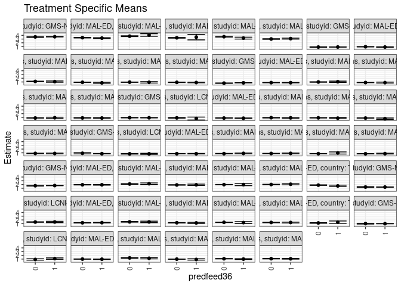

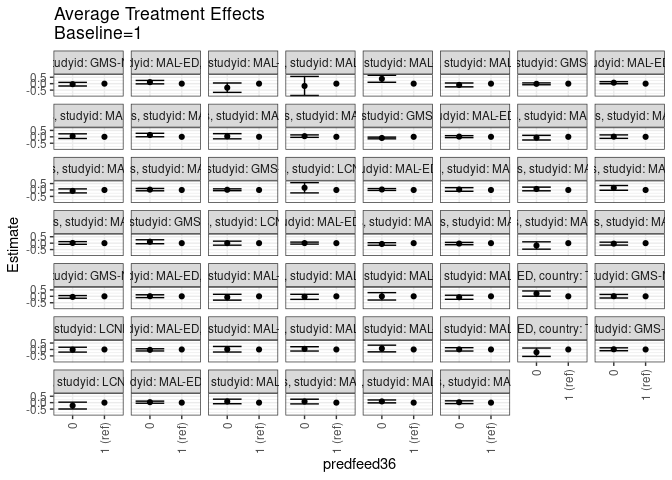

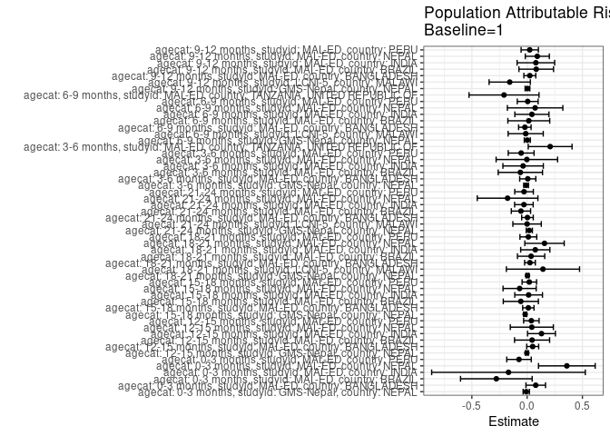

## Results Table

### Parameter: TSM

| agecat | studyid | country | intervention_level | baseline_level | estimate | ci_lower | ci_upper |
| --- | --- | --- | --- | --- | --- | --- | --- |
| 0-3 months | GMS-Nepal | NEPAL | 1 | NA | 3.6253644 | 3.5675080 | 3.6832209 |
| 0-3 months | GMS-Nepal | NEPAL | 0 | NA | 3.5854484 | 3.4559271 | 3.7149698 |
| 0-3 months | MAL-ED | BANGLADESH | 1 | NA | 3.2625667 | 3.1597487 | 3.3653846 |
| 0-3 months | MAL-ED | BANGLADESH | 0 | NA | 3.3792835 | 3.2954697 | 3.4630972 |
| 0-3 months | MAL-ED | BRAZIL | 1 | NA | 4.0871286 | 3.7403101 | 4.4339471 |
| 0-3 months | MAL-ED | BRAZIL | 0 | NA | 3.7728038 | 3.6589657 | 3.8866418 |
| 0-3 months | MAL-ED | INDIA | 1 | NA | 3.5185166 | 2.7845702 | 4.2524631 |
| 0-3 months | MAL-ED | INDIA | 0 | NA | 3.3389972 | 3.2454040 | 3.4325903 |
| 0-3 months | MAL-ED | NEPAL | 1 | NA | 3.2566947 | 3.0041285 | 3.5092609 |
| 0-3 months | MAL-ED | NEPAL | 0 | NA | 3.6355630 | 3.5400307 | 3.7310953 |
| 0-3 months | MAL-ED | PERU | 1 | NA | 3.1225747 | 2.9941209 | 3.2510285 |
| 0-3 months | MAL-ED | PERU | 0 | NA | 3.0228865 | 2.9453083 | 3.1004648 |
| 3-6 months | GMS-Nepal | NEPAL | 1 | NA | 1.7180444 | 1.6744326 | 1.7616562 |
| 3-6 months | GMS-Nepal | NEPAL | 0 | NA | 1.6716342 | 1.5771432 | 1.7661253 |
| 3-6 months | MAL-ED | BANGLADESH | 1 | NA | 1.9205024 | 1.8288466 | 2.0121583 |
| 3-6 months | MAL-ED | BANGLADESH | 0 | NA | 1.9289220 | 1.8688940 | 1.9889500 |
| 3-6 months | MAL-ED | BRAZIL | 1 | NA | 2.2074793 | 1.9962551 | 2.4187035 |
| 3-6 months | MAL-ED | BRAZIL | 0 | NA | 2.1376939 | 2.0524805 | 2.2229073 |
| 3-6 months | MAL-ED | INDIA | 1 | NA | 1.9212981 | 1.7352710 | 2.1073252 |
| 3-6 months | MAL-ED | INDIA | 0 | NA | 1.8819167 | 1.8152509 | 1.9485824 |
| 3-6 months | MAL-ED | NEPAL | 1 | NA | 1.9686909 | 1.6865490 | 2.2508327 |
| 3-6 months | MAL-ED | NEPAL | 0 | NA | 1.9659877 | 1.9085533 | 2.0234221 |
| 3-6 months | MAL-ED | PERU | 1 | NA | 2.0697886 | 1.9301510 | 2.2094262 |
| 3-6 months | MAL-ED | PERU | 0 | NA | 1.9964565 | 1.9218611 | 2.0710519 |
| 3-6 months | MAL-ED | TANZANIA, UNITED REPUBLIC OF | 1 | NA | 1.6207289 | 1.4299522 | 1.8115056 |
| 3-6 months | MAL-ED | TANZANIA, UNITED REPUBLIC OF | 0 | NA | 1.8334280 | 1.7636111 | 1.9032449 |
| 6-9 months | GMS-Nepal | NEPAL | 1 | NA | 1.3130344 | 1.2731058 | 1.3529631 |
| 6-9 months | GMS-Nepal | NEPAL | 0 | NA | 1.3203276 | 1.1881506 | 1.4525046 |
| 6-9 months | LCNI-5 | MALAWI | 1 | NA | 1.4504298 | 1.2732863 | 1.6275734 |
| 6-9 months | LCNI-5 | MALAWI | 0 | NA | 1.4347776 | 1.3694403 | 1.5001149 |

[output cut: 78 more lines]

### Parameter: E(Y)

| agecat | studyid | country | intervention_level | baseline_level | estimate | ci_lower | ci_upper |
| --- | --- | --- | --- | --- | --- | --- | --- |
| 0-3 months | GMS-Nepal | NEPAL | NA | NA | 3.6173812 | 3.5643204 | 3.6704421 |
| 0-3 months | MAL-ED | BANGLADESH | NA | NA | 3.3402171 | 3.2743239 | 3.4061103 |
| 0-3 months | MAL-ED | BRAZIL | NA | NA | 3.8085653 | 3.6991781 | 3.9179525 |
| 0-3 months | MAL-ED | INDIA | NA | NA | 3.3499072 | 3.2511340 | 3.4486803 |
| 0-3 months | MAL-ED | NEPAL | NA | NA | 3.6158815 | 3.5234019 | 3.7083612 |
| 0-3 months | MAL-ED | PERU | NA | NA | 3.0490404 | 2.9824173 | 3.1156636 |
| 3-6 months | GMS-Nepal | NEPAL | NA | NA | 1.7085606 | 1.6688133 | 1.7483079 |
| 3-6 months | MAL-ED | BANGLADESH | NA | NA | 1.9261033 | 1.8757410 | 1.9764655 |
| 3-6 months | MAL-ED | BRAZIL | NA | NA | 2.1460815 | 2.0668679 | 2.2252951 |
| 3-6 months | MAL-ED | INDIA | NA | NA | 1.8848530 | 1.8216037 | 1.9481024 |
| 3-6 months | MAL-ED | NEPAL | NA | NA | 1.9660809 | 1.9097800 | 2.0223819 |
| 3-6 months | MAL-ED | PERU | NA | NA | 2.0156821 | 1.9494666 | 2.0818976 |
| 3-6 months | MAL-ED | TANZANIA, UNITED REPUBLIC OF | NA | NA | 1.8289025 | 1.7605509 | 1.8972540 |
| 6-9 months | GMS-Nepal | NEPAL | NA | NA | 1.3144775 | 1.2731267 | 1.3558284 |
| 6-9 months | LCNI-5 | MALAWI | NA | NA | 1.4372604 | 1.3755150 | 1.4990057 |
| 6-9 months | MAL-ED | BANGLADESH | NA | NA | 1.2480451 | 1.2083209 | 1.2877694 |
| 6-9 months | MAL-ED | BRAZIL | NA | NA | 1.4831159 | 1.4026580 | 1.5635738 |
| 6-9 months | MAL-ED | INDIA | NA | NA | 1.2403346 | 1.1889010 | 1.2917682 |
| 6-9 months | MAL-ED | NEPAL | NA | NA | 1.3587924 | 1.3145651 | 1.4030198 |
| 6-9 months | MAL-ED | PERU | NA | NA | 1.3199965 | 1.2656612 | 1.3743319 |
| 6-9 months | MAL-ED | TANZANIA, UNITED REPUBLIC OF | NA | NA | 1.1929853 | 1.1149435 | 1.2710272 |
| 9-12 months | GMS-Nepal | NEPAL | NA | NA | 0.9984152 | 0.9640726 | 1.0327578 |
| 9-12 months | LCNI-5 | MALAWI | NA | NA | 0.9706344 | 0.8246089 | 1.1166600 |
| 9-12 months | MAL-ED | BANGLADESH | NA | NA | 0.9896446 | 0.9509752 | 1.0283140 |
| 9-12 months | MAL-ED | BRAZIL | NA | NA | 1.2982559 | 1.2240694 | 1.3724425 |
| 9-12 months | MAL-ED | INDIA | NA | NA | 0.9798686 | 0.9411954 | 1.0185419 |
| 9-12 months | MAL-ED | NEPAL | NA | NA | 1.0883592 | 1.0474563 | 1.1292621 |
| 9-12 months | MAL-ED | PERU | NA | NA | 1.0985124 | 1.0475959 | 1.1494289 |
| 12-15 months | GMS-Nepal | NEPAL | NA | NA | 0.8702474 | 0.8441404 | 0.8963544 |
| 12-15 months | MAL-ED | BANGLADESH | NA | NA | 0.9141004 | 0.8737459 | 0.9544550 |
| 12-15 months | MAL-ED | BRAZIL | NA | NA | 1.1421774 | 1.0831447 | 1.2012100 |
| 12-15 months | MAL-ED | INDIA | NA | NA | 0.9075845 | 0.8681682 | 0.9470009 |
| 12-15 months | MAL-ED | NEPAL | NA | NA | 0.9512824 | 0.9117179 | 0.9908469 |
| 12-15 months | MAL-ED | PERU | NA | NA | 0.8917280 | 0.8454370 | 0.9380189 |
| 15-18 months | GMS-Nepal | NEPAL | NA | NA | 0.7596809 | 0.7265174 | 0.7928444 |
| 15-18 months | MAL-ED | BANGLADESH | NA | NA | 0.8241226 | 0.7871907 | 0.8610544 |
| 15-18 months | MAL-ED | BRAZIL | NA | NA | 1.0021114 | 0.9429996 | 1.0612232 |
| 15-18 months | MAL-ED | INDIA | NA | NA | 0.8476806 | 0.8113849 | 0.8839763 |
| 15-18 months | MAL-ED | NEPAL | NA | NA | 0.8406068 | 0.7989917 | 0.8822220 |
| 15-18 months | MAL-ED | PERU | NA | NA | 0.8534307 | 0.8111406 | 0.8957208 |
| 18-21 months | GMS-Nepal | NEPAL | NA | NA | 0.9045343 | 0.8683581 | 0.9407104 |
| 18-21 months | LCNI-5 | MALAWI | NA | NA | 0.8419773 | 0.7481346 | 0.9358201 |
| 18-21 months | MAL-ED | BANGLADESH | NA | NA | 0.8133847 | 0.7790076 | 0.8477619 |
| 18-21 months | MAL-ED | BRAZIL | NA | NA | 0.9160758 | 0.8452655 | 0.9868862 |
| 18-21 months | MAL-ED | INDIA | NA | NA | 0.8759623 | 0.8406388 | 0.9112858 |
| 18-21 months | MAL-ED | NEPAL | NA | NA | 0.8178484 | 0.7795814 | 0.8561153 |
| 18-21 months | MAL-ED | PERU | NA | NA | 0.8414439 | 0.7967949 | 0.8860929 |
| 21-24 months | GMS-Nepal | NEPAL | NA | NA | 0.7920360 | 0.7445193 | 0.8395527 |
| 21-24 months | LCNI-5 | MALAWI | NA | NA | 0.7342569 | 0.6662316 | 0.8022822 |
| 21-24 months | MAL-ED | BANGLADESH | NA | NA | 0.7694183 | 0.7339448 | 0.8048918 |
| 21-24 months | MAL-ED | BRAZIL | NA | NA | 0.7961519 | 0.7521041 | 0.8401997 |
| 21-24 months | MAL-ED | INDIA | NA | NA | 0.8269217 | 0.7961503 | 0.8576932 |
| 21-24 months | MAL-ED | NEPAL | NA | NA | 0.7833446 | 0.7424130 | 0.8242761 |
| 21-24 months | MAL-ED | PERU | NA | NA | 0.7610506 | 0.7141593 | 0.8079419 |

### Parameter: ATE

| agecat | studyid | country | intervention_level | baseline_level | estimate | ci_lower | ci_upper |
| --- | --- | --- | --- | --- | --- | --- | --- |
| 0-3 months | GMS-Nepal | NEPAL | 1 | 1 | 0.0000000 | 0.0000000 | 0.0000000 |
| 0-3 months | GMS-Nepal | NEPAL | 0 | 1 | -0.0399160 | -0.1817721 | 0.1019400 |
| 0-3 months | MAL-ED | BANGLADESH | 1 | 1 | 0.0000000 | 0.0000000 | 0.0000000 |
| 0-3 months | MAL-ED | BANGLADESH | 0 | 1 | 0.1167168 | -0.0159342 | 0.2493677 |
| 0-3 months | MAL-ED | BRAZIL | 1 | 1 | 0.0000000 | 0.0000000 | 0.0000000 |
| 0-3 months | MAL-ED | BRAZIL | 0 | 1 | -0.3143248 | -0.6793483 | 0.0506987 |
| 0-3 months | MAL-ED | INDIA | 1 | 1 | 0.0000000 | 0.0000000 | 0.0000000 |
| 0-3 months | MAL-ED | INDIA | 0 | 1 | -0.1795195 | -0.9194094 | 0.5603704 |
| 0-3 months | MAL-ED | NEPAL | 1 | 1 | 0.0000000 | 0.0000000 | 0.0000000 |
| 0-3 months | MAL-ED | NEPAL | 0 | 1 | 0.3788683 | 0.1088384 | 0.6488981 |
| 0-3 months | MAL-ED | PERU | 1 | 1 | 0.0000000 | 0.0000000 | 0.0000000 |
| 0-3 months | MAL-ED | PERU | 0 | 1 | -0.0996882 | -0.2497507 | 0.0503743 |
| 3-6 months | GMS-Nepal | NEPAL | 1 | 1 | 0.0000000 | 0.0000000 | 0.0000000 |
| 3-6 months | GMS-Nepal | NEPAL | 0 | 1 | -0.0464102 | -0.1504800 | 0.0576597 |
| 3-6 months | MAL-ED | BANGLADESH | 1 | 1 | 0.0000000 | 0.0000000 | 0.0000000 |
| 3-6 months | MAL-ED | BANGLADESH | 0 | 1 | 0.0084196 | -0.1011439 | 0.1179830 |
| 3-6 months | MAL-ED | BRAZIL | 1 | 1 | 0.0000000 | 0.0000000 | 0.0000000 |
| 3-6 months | MAL-ED | BRAZIL | 0 | 1 | -0.0697854 | -0.2975507 | 0.1579798 |
| 3-6 months | MAL-ED | INDIA | 1 | 1 | 0.0000000 | 0.0000000 | 0.0000000 |
| 3-6 months | MAL-ED | INDIA | 0 | 1 | -0.0393814 | -0.2369932 | 0.1582303 |
| 3-6 months | MAL-ED | NEPAL | 1 | 1 | 0.0000000 | 0.0000000 | 0.0000000 |
| 3-6 months | MAL-ED | NEPAL | 0 | 1 | -0.0027032 | -0.2906315 | 0.2852252 |
| 3-6 months | MAL-ED | PERU | 1 | 1 | 0.0000000 | 0.0000000 | 0.0000000 |
| 3-6 months | MAL-ED | PERU | 0 | 1 | -0.0733321 | -0.2316456 | 0.0849813 |
| 3-6 months | MAL-ED | TANZANIA, UNITED REPUBLIC OF | 1 | 1 | 0.0000000 | 0.0000000 | 0.0000000 |
| 3-6 months | MAL-ED | TANZANIA, UNITED REPUBLIC OF | 0 | 1 | 0.2126991 | 0.0095485 | 0.4158496 |
| 6-9 months | GMS-Nepal | NEPAL | 1 | 1 | 0.0000000 | 0.0000000 | 0.0000000 |
| 6-9 months | GMS-Nepal | NEPAL | 0 | 1 | 0.0072932 | -0.1307831 | 0.1453694 |
| 6-9 months | LCNI-5 | MALAWI | 1 | 1 | 0.0000000 | 0.0000000 | 0.0000000 |
| 6-9 months | LCNI-5 | MALAWI | 0 | 1 | -0.0156522 | -0.2044611 | 0.1731567 |

[output cut: 78 more lines]

### Parameter: PAR

| agecat | studyid | country | intervention_level | baseline_level | estimate | ci_lower | ci_upper |
| --- | --- | --- | --- | --- | --- | --- | --- |
| 0-3 months | GMS-Nepal | NEPAL | 1 | NA | -0.0079832 | -0.0363916 | 0.0204252 |
| 0-3 months | MAL-ED | BANGLADESH | 1 | NA | 0.0776504 | -0.0108744 | 0.1661752 |
| 0-3 months | MAL-ED | BRAZIL | 1 | NA | -0.2785633 | -0.6024133 | 0.0452867 |
| 0-3 months | MAL-ED | INDIA | 1 | NA | -0.1686095 | -0.8635619 | 0.5263430 |
| 0-3 months | MAL-ED | NEPAL | 1 | NA | 0.3591868 | 0.1028381 | 0.6155356 |
| 0-3 months | MAL-ED | PERU | 1 | NA | -0.0735342 | -0.1843540 | 0.0372856 |
| 3-6 months | GMS-Nepal | NEPAL | 1 | NA | -0.0094838 | -0.0308191 | 0.0118514 |
| 3-6 months | MAL-ED | BANGLADESH | 1 | NA | 0.0056008 | -0.0672845 | 0.0784862 |
| 3-6 months | MAL-ED | BRAZIL | 1 | NA | -0.0613978 | -0.2618112 | 0.1390157 |
| 3-6 months | MAL-ED | INDIA | 1 | NA | -0.0364451 | -0.2193276 | 0.1464374 |
| 3-6 months | MAL-ED | NEPAL | 1 | NA | -0.0026100 | -0.2806098 | 0.2753898 |
| 3-6 months | MAL-ED | PERU | 1 | NA | -0.0541065 | -0.1709788 | 0.0627658 |
| 3-6 months | MAL-ED | TANZANIA, UNITED REPUBLIC OF | 1 | NA | 0.2081736 | 0.0100628 | 0.4062844 |
| 6-9 months | GMS-Nepal | NEPAL | 1 | NA | 0.0014431 | -0.0258796 | 0.0287659 |
| 6-9 months | LCNI-5 | MALAWI | 1 | NA | -0.0131694 | -0.1720321 | 0.1456932 |
| 6-9 months | MAL-ED | BANGLADESH | 1 | NA | -0.0206172 | -0.0770531 | 0.0358186 |
| 6-9 months | MAL-ED | BRAZIL | 1 | NA | 0.0149305 | -0.1743705 | 0.2042315 |
| 6-9 months | MAL-ED | INDIA | 1 | NA | 0.0431447 | -0.1109938 | 0.1972832 |
| 6-9 months | MAL-ED | NEPAL | 1 | NA | 0.0721413 | -0.1787411 | 0.3230238 |
| 6-9 months | MAL-ED | PERU | 1 | NA | 0.0051406 | -0.0891054 | 0.0993867 |
| 6-9 months | MAL-ED | TANZANIA, UNITED REPUBLIC OF | 1 | NA | -0.2091025 | -0.5257761 | 0.1075711 |
| 9-12 months | GMS-Nepal | NEPAL | 1 | NA | 0.0029443 | -0.0185331 | 0.0244216 |
| 9-12 months | LCNI-5 | MALAWI | 1 | NA | -0.1576408 | -0.3440762 | 0.0287946 |
| 9-12 months | MAL-ED | BANGLADESH | 1 | NA | 0.0243261 | -0.0296723 | 0.0783246 |
| 9-12 months | MAL-ED | BRAZIL | 1 | NA | 0.0820961 | -0.0744216 | 0.2386138 |
| 9-12 months | MAL-ED | INDIA | 1 | NA | 0.0789594 | -0.0910715 | 0.2489903 |
| 9-12 months | MAL-ED | NEPAL | 1 | NA | 0.0919867 | -0.0168464 | 0.2008198 |
| 9-12 months | MAL-ED | PERU | 1 | NA | 0.0234981 | -0.0546855 | 0.1016817 |
| 12-15 months | GMS-Nepal | NEPAL | 1 | NA | -0.0027055 | -0.0169047 | 0.0114937 |
| 12-15 months | MAL-ED | BANGLADESH | 1 | NA | 0.0501816 | -0.0040137 | 0.1043768 |
| 12-15 months | MAL-ED | BRAZIL | 1 | NA | 0.0446596 | -0.1138904 | 0.2032096 |
| 12-15 months | MAL-ED | INDIA | 1 | NA | 0.1297353 | 0.0036808 | 0.2557899 |
| 12-15 months | MAL-ED | NEPAL | 1 | NA | 0.0423720 | -0.1523408 | 0.2370847 |
| 12-15 months | MAL-ED | PERU | 1 | NA | 0.0382087 | -0.0317459 | 0.1081632 |
| 15-18 months | GMS-Nepal | NEPAL | 1 | NA | -0.0179141 | -0.0314141 | -0.0044140 |
| 15-18 months | MAL-ED | BANGLADESH | 1 | NA | 0.0108647 | -0.0403547 | 0.0620841 |
| 15-18 months | MAL-ED | BRAZIL | 1 | NA | -0.0571028 | -0.2159791 | 0.1017735 |
| 15-18 months | MAL-ED | INDIA | 1 | NA | 0.0134819 | -0.1117305 | 0.1386943 |
| 15-18 months | MAL-ED | NEPAL | 1 | NA | -0.0680421 | -0.2179979 | 0.0819138 |
| 15-18 months | MAL-ED | PERU | 1 | NA | 0.0197400 | -0.0458360 | 0.0853161 |
| 18-21 months | GMS-Nepal | NEPAL | 1 | NA | 0.0031190 | -0.0102824 | 0.0165204 |
| 18-21 months | LCNI-5 | MALAWI | 1 | NA | 0.1431401 | -0.1878191 | 0.4740993 |
| 18-21 months | MAL-ED | BANGLADESH | 1 | NA | 0.0256920 | -0.0228291 | 0.0742132 |
| 18-21 months | MAL-ED | BRAZIL | 1 | NA | 0.0357254 | -0.0874572 | 0.1589079 |
| 18-21 months | MAL-ED | INDIA | 1 | NA | 0.0736048 | -0.0583455 | 0.2055551 |
| 18-21 months | MAL-ED | NEPAL | 1 | NA | 0.1571422 | -0.0209289 | 0.3352134 |
| 18-21 months | MAL-ED | PERU | 1 | NA | 0.0109198 | -0.0650948 | 0.0869345 |
| 21-24 months | GMS-Nepal | NEPAL | 1 | NA | 0.0194712 | -0.0083883 | 0.0473308 |
| 21-24 months | LCNI-5 | MALAWI | 1 | NA | -0.0005003 | -0.1290488 | 0.1280483 |
| 21-24 months | MAL-ED | BANGLADESH | 1 | NA | 0.0029349 | -0.0493532 | 0.0552231 |
| 21-24 months | MAL-ED | BRAZIL | 1 | NA | -0.0560130 | -0.1432807 | 0.0312548 |
| 21-24 months | MAL-ED | INDIA | 1 | NA | -0.0292400 | -0.1131136 | 0.0546337 |
| 21-24 months | MAL-ED | NEPAL | 1 | NA | -0.1768696 | -0.4510639 | 0.0973247 |
| 21-24 months | MAL-ED | PERU | 1 | NA | -0.0280673 | -0.1121330 | 0.0559984 |